# Assignment4_PML

Nandan Tavargeri

23/10/2021

##Synopsis

Using devices such as Jawbone Up, Nike FuelBand, and Fitbit it is now possible to collect a large amount of data about personal activity relatively inexpensively. These type of devices are part of the quantified self movement – a group of enthusiasts who take measurements about themselves regularly to improve their health, to find patterns in their behavior, or because they are tech geeks. One thing that people regularly do is quantify how much of a particular activity they do, but they rarely quantify how well they do it. In this project, your goal will be to use data from accelerometers on the belt, forearm, arm, and dumbell of 6 participants. They were asked to perform barbell lifts correctly and incorrectly in 5 different ways.

The goal of this project is to predict the manner in which they did the exercise. This is the `classe` variable in the training set.

## Data description

The outcome variable is `classe`, a factor variable with 5 levels. For this data set, participants were asked to perform one set of 10 repetitions of the Unilateral Dumbbell Biceps Curl in 5 different fashions:

- exactly according to the specification (Class A)
- throwing the elbows to the front (Class B)
- lifting the dumbbell only halfway (Class C)
- lowering the dumbbell only halfway (Class D)
- throwing the hips to the front (Class E)

## Initial configuration

First we import the required modules into the program. We follow this by loading the dataset into two seperate dataframes, namely the “training” and “testing” dataframes

```r
#Importing Modules
library(caret)
library(rpart)
```

```r
library(rpart.plot)
library(RColorBrewer)
library(RGtk2)
library(rattle)
library(randomForest)
library(gbm)
#Loading the datasets
train_url <- "http://d396qusza40orc.cloudfront.net/predmachlearn/pml-training.csv"
test_url  <- "http://d396qusza40orc.cloudfront.net/predmachlearn/pml-testing.csv"
init_org_training_data <- read.csv(url(train_url))
init_org_testing_data <- read.csv(url(test_url))
dim(init_org_training_data)
```

```
## [1] 19622   160
```

```r
dim(init_org_testing_data)
```

```
## [1]  20 160
```

## Data processing

Here the data is cleaned

```r
non_zero_var <- nearZeroVar(init_org_training_data)
org_training_data <- init_org_training_data[,-non_zero_var]
org_testing_data <- init_org_testing_data[,-non_zero_var]
dim(org_training_data)
```

```
## [1] 19622   100
```

```r
dim(org_testing_data)
```

```
## [1]  20 100
```

```r
na_val_col <- sapply(org_training_data, function(x) mean(is.na(x))) > 0.95
org_training_data <- org_training_data[,na_val_col == FALSE]
org_testing_data <- org_testing_data[,na_val_col == FALSE]
dim(org_training_data)
```

```
## [1] 19622    59
```

```r
dim(org_testing_data)
```

```
## [1] 20 59
```

```r
org_training_data <- org_training_data[,8:59]
org_testing_data <- org_testing_data[,8:59]
dim(org_training_data)
```

```
## [1] 19622    52
```

```r
dim(org_testing_data)
```

```
## [1] 20 52
```

## Cross-validation

In this section cross-validation will be performed by splitting the training data in training (60%) and testing (40%) data.

```r
inTrain <- createDataPartition(org_training_data$classe, p=0.6, list=FALSE)
training <- org_training_data[inTrain,]
testing <- org_training_data[-inTrain,]
dim(training)
```

```
## [1] 11776    52
```

```r
dim(testing)
```

```
## [1] 7846   52
```

## Decision Tree Model

```r
DT_modfit <- train(classe ~ ., data = training, method="rpart")
DT_prediction <- predict(DT_modfit, testing)
confusionMatrix(as.factor(DT_prediction), as.factor(testing$classe))
```

```
## Confusion Matrix and Statistics
##
##           Reference
## Prediction    A    B    C    D    E
##          A 2031  629  623  593  315
##          B   28  523   45  217  268
##          C  127  318  573  189  362
##          D   36   48  127  287   54
##          E   10    0    0    0  443
##
## Overall Statistics
##
##                Accuracy : 0.4916
##                  95% CI : (0.4805, 0.5027)
##     No Information Rate : 0.2845
##     P-Value [Acc > NIR] : < 2.2e-16
##
##                   Kappa : 0.3349
##
##  Mcnemar's Test P-Value : < 2.2e-16
##
## Statistics by Class:
##
##                      Class: A Class: B Class: C Class: D Class: E
## Sensitivity            0.9099  0.34453  0.41886  0.22317  0.30721
## Specificity            0.6152  0.91182  0.84625  0.95960  0.99844
## Pos Pred Value         0.4846  0.48381  0.36520  0.51993  0.97792
## Neg Pred Value         0.9450  0.85292  0.87335  0.86304  0.86487
## Prevalence             0.2845  0.19347  0.17436  0.16391  0.18379
## Detection Rate         0.2589  0.06666  0.07303  0.03658  0.05646
## Detection Prevalence   0.5342  0.13778  0.19997  0.07035  0.05774
## Balanced Accuracy      0.7626  0.62818  0.63255  0.59139  0.65283
```

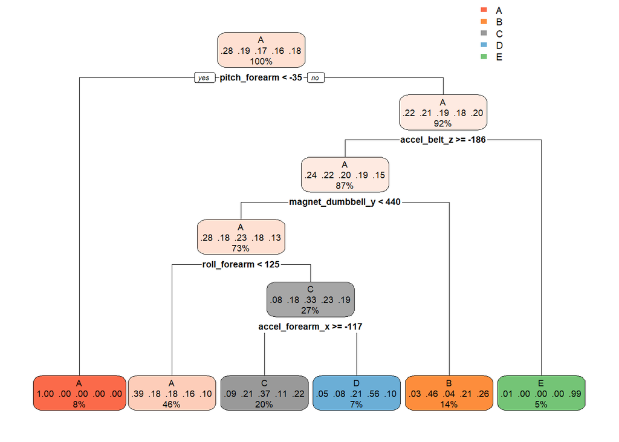

```r
rpart.plot(DT_modfit$finalModel, roundint=FALSE)
```

We can see that the prediction accuracy is 50% which is not upto the desired level.

## Random Forest Model

```r
RF_modfit <- train(classe ~ ., data = training, method = "rf", ntree = 100)
RF_prediction <- predict(RF_modfit, testing)
RF_pred_conf <- confusionMatrix(as.factor(RF_prediction), as.factor(testing$classe))
RF_pred_conf
```

```
## Confusion Matrix and Statistics
##
##           Reference
## Prediction    A    B    C    D    E
##          A 2226   11    0    0    0
##          B    5 1495    7    0    0
##          C    0   10 1354   16    3
##          D    0    1    7 1268    1
##          E    1    1    0    2 1438
##
## Overall Statistics
##
##                Accuracy : 0.9917
##                  95% CI : (0.9895, 0.9936)
##     No Information Rate : 0.2845
##     P-Value [Acc > NIR] : < 2.2e-16
##
##                   Kappa : 0.9895
##
##  Mcnemar's Test P-Value : NA
##
## Statistics by Class:
##
##                      Class: A Class: B Class: C Class: D Class: E
## Sensitivity            0.9973   0.9848   0.9898   0.9860   0.9972
## Specificity            0.9980   0.9981   0.9955   0.9986   0.9994
## Pos Pred Value         0.9951   0.9920   0.9790   0.9930   0.9972
## Neg Pred Value         0.9989   0.9964   0.9978   0.9973   0.9994
## Prevalence             0.2845   0.1935   0.1744   0.1639   0.1838
## Detection Rate         0.2837   0.1905   0.1726   0.1616   0.1833
## Detection Prevalence   0.2851   0.1921   0.1763   0.1628   0.1838
## Balanced Accuracy      0.9977   0.9915   0.9926   0.9923   0.9983
```

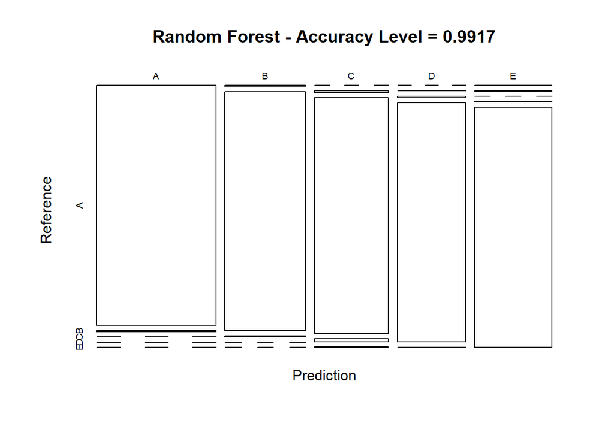

```r
plot(RF_pred_conf$table, col = RF_pred_conf$byClass,
     main = paste("Random Forest - Accuracy Level =",
                  round(RF_pred_conf$overall['Accuracy'], 4)))
```

##Gradient Boosting Model

```r
GBM_modfit <- train(classe ~ ., data = training, method = "gbm", verbose = FALSE)
GBM_modfit$finalModel
```

```
## A gradient boosted model with multinomial loss function.
## 150 iterations were performed.
## There were 51 predictors of which 51 had non-zero influence.
```

```r
GBM_prediction <- predict(GBM_modfit, testing)

GBM_pred_conf <- confusionMatrix(as.factor(GBM_prediction), as.factor(testing$classe))
GBM_pred_conf
```

```
## Confusion Matrix and Statistics
##
##           Reference
## Prediction    A    B    C    D    E
##          A 2201   57    0    3    0
##          B   20 1406   42    7   10
##          C    8   42 1304   41   10
##          D    3    7   17 1228   20
##          E    0    6    5    7 1402
##
## Overall Statistics
##
##                Accuracy : 0.9611
##                  95% CI : (0.9566, 0.9653)
##     No Information Rate : 0.2845
##     P-Value [Acc > NIR] : < 2.2e-16
##
##                   Kappa : 0.9508
##
##  Mcnemar's Test P-Value : NA
##
## Statistics by Class:
##
##                      Class: A Class: B Class: C Class: D Class: E
## Sensitivity            0.9861   0.9262   0.9532   0.9549   0.9723
## Specificity            0.9893   0.9875   0.9844   0.9928   0.9972
## Pos Pred Value         0.9735   0.9468   0.9281   0.9631   0.9873
## Neg Pred Value         0.9944   0.9824   0.9901   0.9912   0.9938
## Prevalence             0.2845   0.1935   0.1744   0.1639   0.1838
## Detection Rate         0.2805   0.1792   0.1662   0.1565   0.1787
## Detection Prevalence   0.2882   0.1893   0.1791   0.1625   0.1810
## Balanced Accuracy      0.9877   0.9569   0.9688   0.9739   0.9847
```

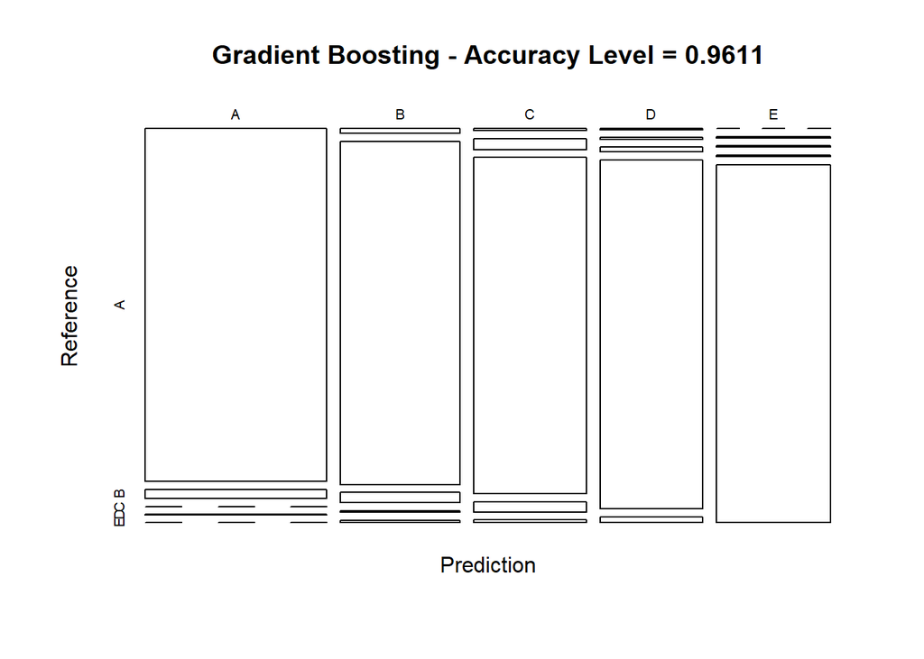

```r
plot(GBM_pred_conf$table, col = GBM_pred_conf$byClass,
     main = paste("Gradient Boosting - Accuracy Level =",
                  round(GBM_pred_conf$overall['Accuracy'], 4)))
```

Now we need to see how each model has predicted the validation dataset across the classifications. We are not considering Decision Tree model as it didn’t reach the satisfactory prediction accuracy level. SO only Random Forest and Gradient Boosting methods are being compared.

```r
RF_pred_conf$overall
```

```
##       Accuracy          Kappa  AccuracyLower  AccuracyUpper   AccuracyNull
##      0.9917155      0.9895205      0.9894528      0.9936006      0.2844762
## AccuracyPValue  McnemarPValue
##      0.0000000            NaN
```

```r
GBM_pred_conf$overall
```

```
##       Accuracy          Kappa  AccuracyLower  AccuracyUpper   AccuracyNull
##      0.9611267      0.9508109      0.9566112      0.9652953      0.2844762
## AccuracyPValue  McnemarPValue
##      0.0000000            NaN
```

## Conclusion

the Random Forest model has definitely more accuracy than GBM. Hence we will be selecting Random Forest model for final prediction from org_testing_data .

### Final Prediction- Applying selected model on the Test Data

```r
Final_RF_prediction <- predict(RF_modfit, org_testing_data )
Final_RF_prediction
```

```
##  [1] B A B A A E D B A A B C B A E E A B B B
## Levels: A B C D E
```